# The Politics of Corruption

Lecture 8: How Corruption Is Measured

Bogdan G. Popescu

bgpopescu@tec.mx

Tecnológico de Monterrey

## Today

If corruption is hidden, how does anyone count it?

You open the hour in a newsroom, with five numbers about Mexico.

- Every number is a **trace** the act left behind
- Four families of trace, and who or what each one observes
- Why what people **believe** and what they **experience** pull apart
- Which measure a claim needs, and the way each one misleads

## One Country, Three Numbers

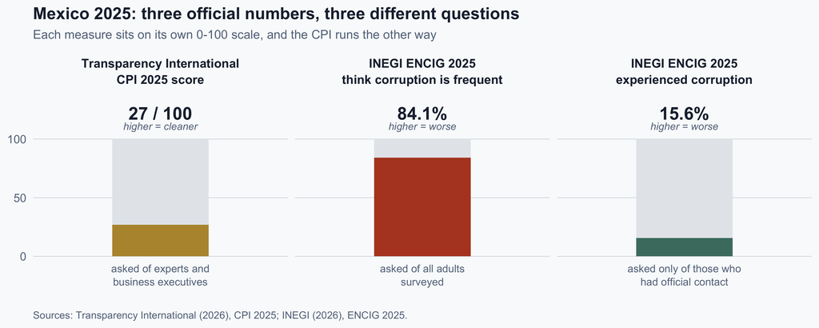

Which number is true?

## Exercise: The Corruption Newsroom

**You are journalists.** Your group has one statistic about corruption in Mexico, and a few minutes to publish.

1. A **headline**: ten words maximum
2. A **subtitle**: twenty-five words maximum, saying what the evidence shows

**The rule.** Your headline should be dramatic. Your subtitle must be exactly true.

## Five Measures of Corruption in Mexico

All of these measure corruption in Mexico.

Table 1: Five published measures of corruption in Mexico.

| What is measured | Type of corruption | Change | Source |
| --- | --- | --- | --- |
| Expert score, public-sector corruption | Bribery, embezzlement, state capture | 29 to 27 (2017-2025) | Transparency International, CPI |
| Adults who say corruption is frequent | Whatever comes to mind | 91.1% to 84.1% (2017-2025) | INEGI, ENCIG |
| People who met corruption in a trámite | Petty bribery of citizens | 14.6% to 15.6% (2017-2025) | INEGI, ENCIG |
| Firms asked for a bribe | Petty bribery of firms | 17.6% to 15.8% (2010-2023) | World Bank, Enterprise Surveys |
| Average paid per corruption victim | Petty bribery of citizens | 3,368 to 3,865 pesos (2023-2025) | INEGI, ENCIG |

## An Example

Built from a sixth statistic, which is on none of the cards.

**Headline.** Where You Live Decides Whether You Pay

**Subtitle.** In 2025, 21.5% of people in Hidalgo who dealt with an official experienced corruption, against 7.0% in Colima.

Source: INEGI (2026), ENCIG 2025.

## Same Country, Five Headlines

Hold on. These all describe corruption in Mexico. Who is wrong?

Table 2: The five cards, and a headline each one actually supports.

| Card | The number | Corruption is | A headline it supports |
| --- | --- | --- | --- |
| A | 29 to 27 | worse | Experts rate Mexico worse on corruption |
| B | 91.1% to 84.1% | BETTER | Fewer Mexicans say corruption is frequent |
| C | 14.6% to 15.6% | worse | More Mexicans report experiencing corruption |
| D | 17.6% to 15.8% | BETTER | Fewer firms report being asked for bribes |
| E | 3,368 to 3,865 pesos | worse | Victims of corruption are paying more |

All five are accurate, because each one counted something different.

# I. Counting Something Hidden

## Why There Are Only Traces

Why can nobody just count the act itself?

- The act is **illegal**, so both sides hide it
- No victim files a report when both parties gained
- Definitions differ: gift, fee, commission, or bribe?
- Researchers can sometimes watch a bribe; usually they cannot
- So a measure settles for what corruption leaves behind

**Measure**: an observable trace we agree to treat as a stand-in for something we cannot see directly.

So each number raises the same question: what left this trace?

On direct observation of bribe payments in the field, see Sequeira (2012).

# II. Four Families of Measure

INEGI headquarters, Mexico City. Photo: Tbhotch, Wikimedia Commons, CC BY-SA 4.0.

## Four Traces of One Hidden Act

```
%%{init: {"theme":"base","width":1150,"height":660,
  "themeVariables":{"fontSize":"19px","fontFamily":"Helvetica, Arial, sans-serif",
    "primaryColor":"#f4f6f8","primaryTextColor":"#1e293b",
    "primaryBorderColor":"#64748b","lineColor":"#334155","textColor":"#1e293b"},
  "flowchart":{"useMaxWidth":true,"htmlLabels":true,"nodeSpacing":28,"rankSpacing":110,
    "curve":"basis","padding":26}} }%%
flowchart LR
  H["A hidden<br/>corrupt act"]
  H --> P["1. Expert<br/>perceptions"]
  H --> E["2. Citizen and<br/>firm experience"]
  H --> A["3. Audits and<br/>missing money"]
  H --> M["4. Market-based<br/>inference"]
  P --> P2["Observed:<br/>expert opinion"]
  E --> E2["Observed:<br/>survey answers"]
  A --> A2["Observed:<br/>quantities built"]
  M --> M2["Observed:<br/>prices"]
  classDef fam fill:#fdf2ef,stroke:#b44527,stroke-width:2px,color:#1e293b;
  classDef obs fill:#eef3f1,stroke:#4a7c6f,stroke-width:2px,color:#1e293b;
  classDef act fill:#1e293b,stroke:#1e293b,color:#f9fafb;
  class H act;
  class P,E,A,M fam;
  class P2,E2,A2,M2 obs;
```

Author’s illustration. Court records and procurement red flags are further families.

## Family 1: Expert Perceptions

The Corruption Perceptions Index, published since 1995.

- Combines **at least 3 of 13** existing surveys and assessments
- Respondents are **country experts and business executives**
- Scale runs 0 (highly corrupt) to 100 (very clean)
- Nobody in the data is asked *“did you pay a bribe?”*
- Covers almost every country every year – its great advantage

Source: Transparency International, *How CPI scores are calculated*.

## What the Experts Are Actually Asked

The CPI itself asks nothing; it aggregates questions like these.

**World Economic Forum, Executive Opinion Survey 2025.** “In your country, how common is it for firms to make undocumented extra payments or bribes connected with the following?” (1 = very common, 7 = never)

1. Imports and exports
2. Public utilities
3. Annual tax payments
4. Awarding of public contracts and licences
5. Obtaining favourable judicial decisions

## The World Through One Index

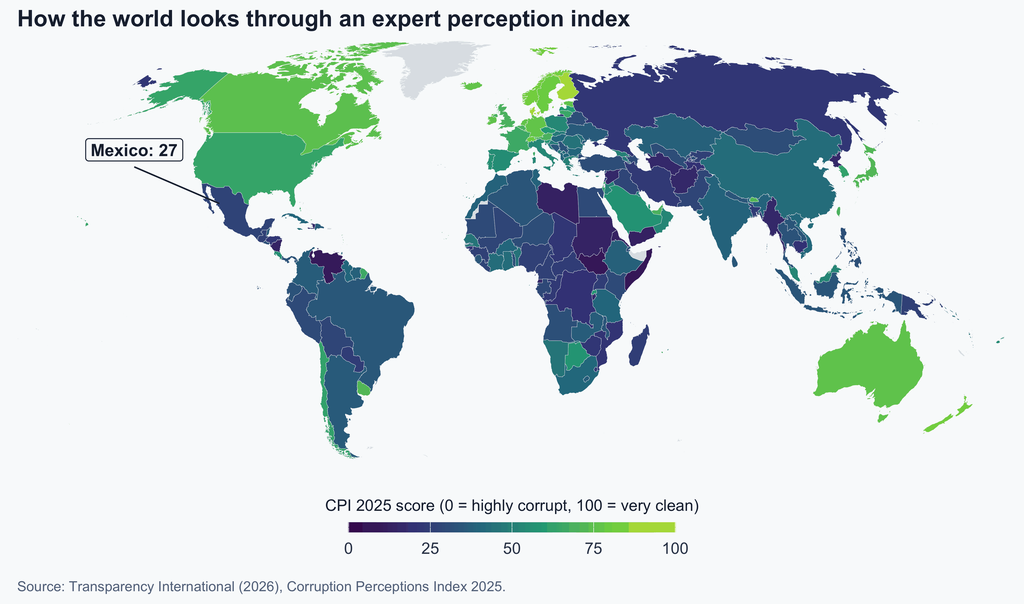

182 countries scored, grey = too few sources. One number per country per year.

## From Thirteen Sources to One Number

The CPI runs no survey of its own; it averages thirteen other people’s.

```
%%{init: {"theme":"base","width":1150,"height":520,
  "themeVariables":{"fontSize":"20px","fontFamily":"Helvetica, Arial, sans-serif",
    "primaryColor":"#f4f6f8","primaryTextColor":"#1e293b",
    "primaryBorderColor":"#64748b","lineColor":"#334155","textColor":"#1e293b"},
  "flowchart":{"useMaxWidth":true,"htmlLabels":true,"nodeSpacing":26,"rankSpacing":55,
    "curve":"basis","padding":30}} }%%
flowchart LR
  A["13 sources<br/>at least 3 per country"] --> B["Rescale each<br/>onto 0-100"]
  B --> C["Simple<br/>average"]
  C --> D["A score,<br/>plus a range"]
  classDef inp fill:#fdf2ef,stroke:#b44527,stroke-width:2px,color:#1e293b;
  classDef step fill:#f4f6f8,stroke:#64748b,stroke-width:2px,color:#1e293b;
  classDef out fill:#eef3f1,stroke:#4a7c6f,stroke-width:2px,color:#1e293b;
  class A inp;
  class B,C step;
  class D out;
```

The range shows how far apart the sources were: wider range, less agreement.

That range has a technical name: a **confidence interval**. You will meet it again; for now, read it as “how much the sources argued”.

Source: Transparency International (2026), *CPI Technical Methodology Note*. Rescaling is a z-score against a baseline year, set to mean 45 and standard deviation 20. Three of the thirteen sources run the opposite way and are reversed first.

## Eight Sources, One Score

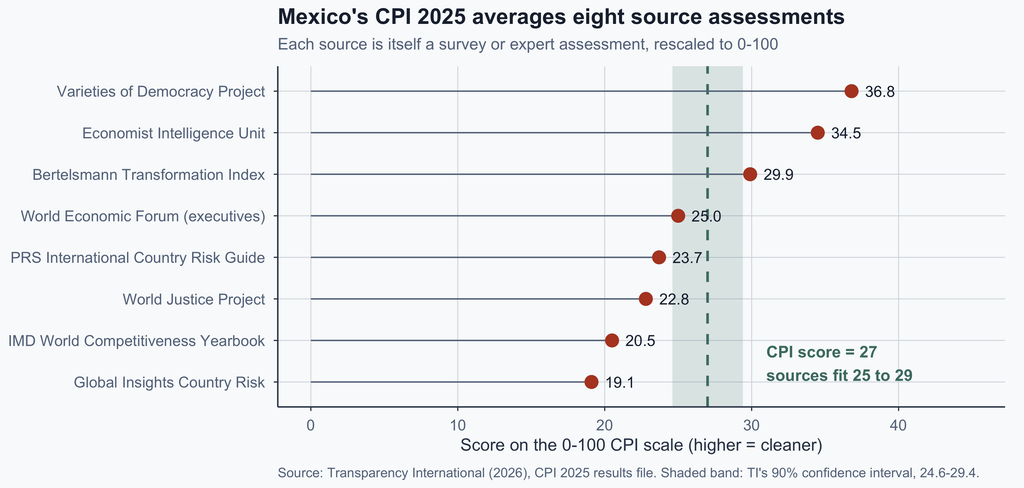

The sources disagree by 18 points about the same country, same year.

## Why the Sources Disagree

Mexico’s eight sources span 19 to 37. Five reasons, none of them error.

- They score different things: bribery, nepotism, state capture
- Some score the machinery instead: prosecutions, disclosure rules, whistleblower protection
- They ask different people: executives, risk analysts, academic experts
- They carry different vintages: Mexico’s run from 2024 to 2026
- Each had its own scale before being rescaled onto 0–100

The composite averages that disagreement away rather than settling it.

Sources: Transparency International (2026), *CPI Technical Methodology Note* and *CPI 2025 Full Source Description*.

## What a Falling Score Means

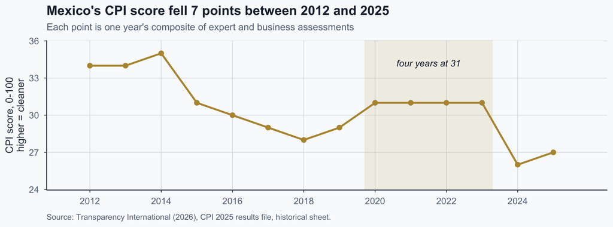

Four years at the same score, then a five-point drop in 2024.

A falling CPI score shows that assessments changed, not yet that behaviour did.

## Family 2: Citizen and Firm Experience

- Asks people what **happened to them**, not what they think
- INEGI’s ENCIG surveys households across urban Mexico
- Enterprise Surveys: **15.8%** of Mexican firms faced a request
- Olken’s survey: 8.9% would not answer the corruption question
- Denominator matters: only people who had **contact** count
- Blind to grand corruption: procurement, contracts, political capture

[figure not shown]

INEGI, Mexico City. Photo: Tbhotch, Wikimedia Commons, CC BY-SA 4.0. Firm figure: World Bank Enterprise Surveys.

## Family 3: Audits and Missing Money

A physical audit, not an opinion.

- Olken studied **477** village road projects in Java
- Engineers measured what was built and priced local materials
- Reported cost minus estimated cost = **missing expenditures**
- On average **24%** of reported spending was missing
- Uganda, 1991–95: schools received just **13%** of grants

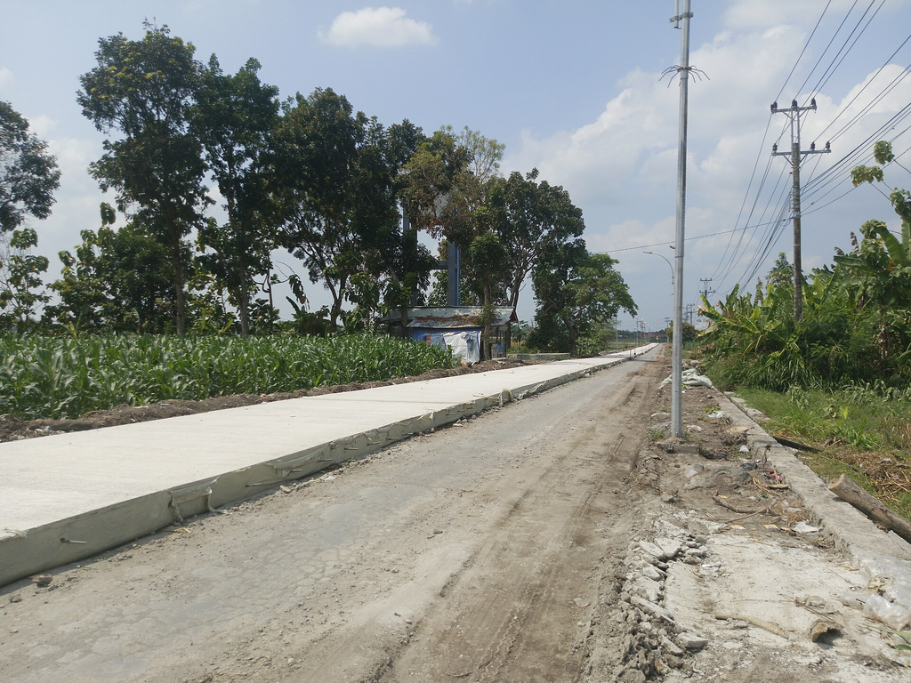

A village road being surfaced, Klaten, Central Java. Photo: Dani Safa Adi Nugraha, [Wikimedia Commons](https://commons.wikimedia.org/wiki/File:Renovasi_Penambahan_Lapisan_Jalan_Lingkar_Utara_Pedan_di_Selatan_Umbul_Kedungan.jpg), CC BY-SA 4.0.

Sources: Olken (2007, 2009); Reinikka and Svensson (2004).

## Where the Money Went Missing

Stealing from the road project: fake the **price**, or the **quantity**?

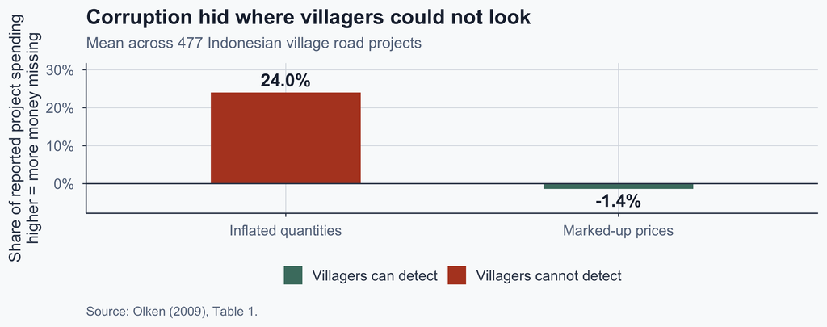

Corruption moved into the dimension observers could not check.

## Why Quantities Are Invisible

[figure not shown]

Aggregate delivery, Marsyangdi valley, Nepal. Photo: Greg Willis, Wikimedia Commons, CC BY-SA 2.0.

- Everyone in the village knows the market price of gravel
- Nobody can eyeball how many cubic metres arrived
- So officials inflated **quantities**, which nobody could check
- Detection shapes the crime, not only our measurement
- Olken’s lesson: auditing needs **specialists**, not just eyes

## Family 4: Market-Based Inference

No one writes the bribe down, but the price is public.

- After Iraq invaded Kuwait, the UN banned Iraqi oil exports
- **Oil for Food** (1997–2003) let it sell, for humanitarian goods
- Every dollar went to a **UN-controlled account**, not to Baghdad
- Iraq still chose **who** was allowed to buy the oil
- Until 2001 it also proposed the price, for UN approval
- It proposed a price **below** the world market

Why would a government sell its own oil too cheap?

Source: Hsieh and Moretti (2006).

## Why Sell It Too Cheap?

Because the oil was cheap, but the **right to buy it** was not.

```
%%{init: {"theme":"base","width":1150,"height":360,
  "themeVariables":{"fontSize":"19px","fontFamily":"Helvetica, Arial, sans-serif",
    "primaryColor":"#f4f6f8","primaryTextColor":"#1e293b",
    "primaryBorderColor":"#64748b","lineColor":"#334155","textColor":"#1e293b"},
  "flowchart":{"useMaxWidth":true,"htmlLabels":true,"nodeSpacing":28,"rankSpacing":58,
    "curve":"basis","padding":26}} }%%
flowchart LR
  A["Oil money locked<br/>in a UN account"] --> B["Sell the oil<br/>below the<br/>market price"]
  B --> C["The discount is<br/>a gift Iraq<br/>hands out"]
  C --> D["Buyer pays cash back<br/>to Baghdad, outside<br/>that account"]
  classDef block fill:#eef3f1,stroke:#4a7c6f,stroke-width:2px,color:#1e293b;
  classDef gift fill:#fdf2ef,stroke:#b44527,stroke-width:2px,color:#1e293b;
  class A,B block;
  class C,D gift;
```

Underprice the asset, then sell the right to buy it.

Like pricing a 150-peso ticket at 100, choosing who may buy one, and pocketing 30 on the side.

## Only Cheap While Iraq Set the Price

Iraqi and Saudi crude are chemically very similar. They normally cost the same.

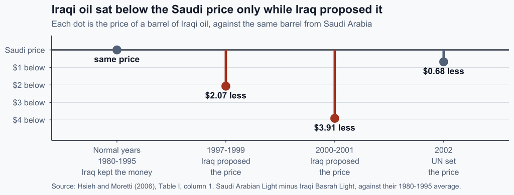

Same oil, same buyers, same market. Only the pricing rule changed.

Seized documents caught $230 million of buyers’ cash to Baghdad. The prices imply **$1.3 billion**.

# III. The Perception–Experience Gap

Roadside in Central Java. Photo: VasenkaPhotography, [Wikimedia Commons](https://commons.wikimedia.org/wiki/File:Java_~_On_the_Road_to_the_Dieng_Plateau_-_6217100461.jpg), CC BY 2.0.

## Twelve Years, Two Different Stories

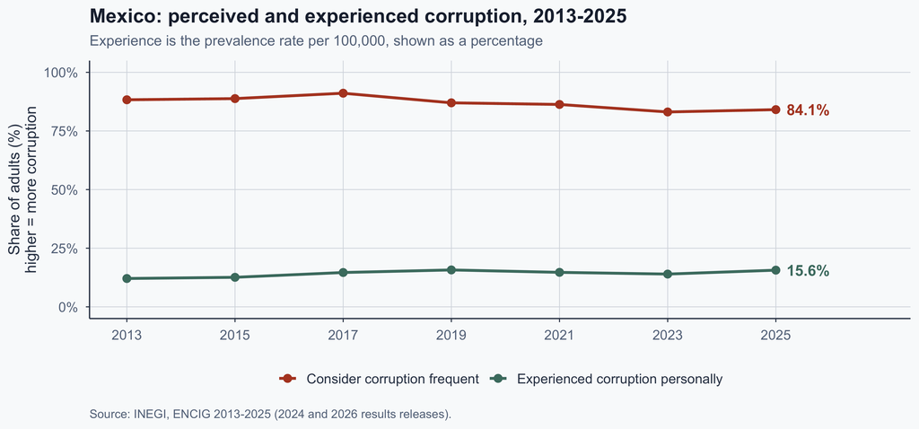

2017 to 2023: perception falls 8 points while experience barely moves.

## Why the Two Diverge

- **Different referent**: the state’s corruption versus my transaction
- **Coverage**: a scandal raises perception without raising bribery
- **Salience**: people recall vivid cases, not their own year
- **Denominator**: experience counts only those who had contact
- **Who answers**: experts assess countries, residents report events
- Richer, more democratic countries score better than experience alone implies

More reporting can raise perceived corruption while experienced corruption falls.

Source on the last point: Donchev and Ujhelyi (2014).

## Do Villagers Know?

Olken asked villagers how much corruption there was in their own road.

- They were partly right: more missing money, more suspicion
- But barely: 10% more missing moves suspicion from 36.0% to 36.3%
- And who you are matters: education and gender shape the answer
- Villages with more ethnic diversity report **more** corruption
- Those same villages lost **less** money

How can the last two both be true?

Source: Olken (2009), 3,691 respondents in 477 villages. Education and gender still shape answers when one village is compared only with itself.

## How Suspicion Can Lower Corruption

One chain makes both of the last two findings true at once.

```
%%{init: {"theme":"base","width":1150,"height":360,
  "themeVariables":{"fontSize":"19px","fontFamily":"Helvetica, Arial, sans-serif",
    "primaryColor":"#f4f6f8","primaryTextColor":"#1e293b",
    "primaryBorderColor":"#64748b","lineColor":"#334155","textColor":"#1e293b"},
  "flowchart":{"useMaxWidth":true,"htmlLabels":true,"nodeSpacing":28,"rankSpacing":58,
    "curve":"basis","padding":26}} }%%
flowchart LR
  A["Diverse village,<br/>less trust<br/>between people"] --> B["More suspicion<br/>of the<br/>officials"]
  B --> C["More of them<br/>turn up and<br/>watch"]
  C --> D["Less money<br/>actually goes<br/>missing"]
  classDef belief fill:#fdf2ef,stroke:#b44527,stroke-width:2px,color:#1e293b;
  classDef doing fill:#eef3f1,stroke:#4a7c6f,stroke-width:2px,color:#1e293b;
  class A,B belief;
  class C,D doing;
```

Suspicion can reduce the thing it measures.

Author’s illustration, after Olken (2009).

## Exercise: Interrogate a Headline

**In pairs.** A newspaper reports: *“Corruption in Mexico rose 20% last year.”*

Write down **every** question you would need answered before believing it.

Then decide: which of your questions would the journalist find hardest?

# IV. Matching Claims to Measures

## What Each Family Can Carry

Table 3: Four families of corruption measure, and their limits.

| Family | Who or what is observed | Claim it can support | How it misleads |
| --- | --- | --- | --- |
| Expert perceptions | Experts, business executives | Broad cross-country comparison | Reputation and news drive the score |
| Citizen and firm experience | Households, firms | Prevalence of petty bribery, and change | Under-reporting; blind to grand corruption |
| Audits and missing money | Physical quantities, records | Leakage in one programme | Costly; one sector at a time |
| Market-based inference | Prices in a market | Size of a hidden transfer in one market | A price gap can have innocent causes |

Author’s synthesis, drawing on Sequeira (2012) and Olken (2009). Not exhaustive: court records, procurement red flags and direct observation are further families.

## So: Better or Worse?

Back to the question the newsroom could not settle.

- Four families: perceptions, experience, audits, market inference
- CPI score fell from 29 to 27 since 2017
- Perceived frequency fell from 91.1% in 2017 to 84.1%
- Experienced corruption rose from 14.6% in 2017 to 15.6%
- Different traces, different trends, different questions
- “It depends what you counted” is the disciplined answer

Every number measures a trace, so ask what left it.

## Conclusion

Five things to carry out of this session.

- Most measures count a **trace**, not the act itself
- Mexico 2025: 84% think it frequent, 16% experienced it
- Eight expert sources scored Mexico anywhere from 19 to 37
- In Java the theft hid in quantities, where nobody could check
- More suspicion and less stolen money can go together

## References

Donchev, D., & Ujhelyi, G. (2014). What do corruption indices measure? *Economics & Politics, 26*(2), 309–331. https://doi.org/10.1111/ecpo.12037

Hsieh, C.-T., & Moretti, E. (2006). Did Iraq cheat the United Nations? Underpricing, bribes, and the Oil for Food Program. *The Quarterly Journal of Economics, 121*(4), 1211–1248.

Instituto Nacional de Estadística y Geografía. (2024). *Encuesta Nacional de Calidad e Impacto Gubernamental (ENCIG) 2023: Principales resultados*. INEGI.

Instituto Nacional de Estadística y Geografía. (2026). *Encuesta Nacional de Calidad e Impacto Gubernamental (ENCIG) 2025* (Comunicado de prensa 28/26; Reporte de resultados 16/26). INEGI.

Olken, B. A. (2007). Monitoring corruption: Evidence from a field experiment in Indonesia. *Journal of Political Economy, 115*(2), 200–249.

Olken, B. A. (2009). Corruption perceptions vs. corruption reality. *Journal of Public Economics, 93*(7–8), 950–964.

## References (continued)

Reinikka, R., & Svensson, J. (2004). Local capture: Evidence from a central government transfer program in Uganda. *The Quarterly Journal of Economics, 119*(2), 679–705.

Sequeira, S. (2012). Advances in measuring corruption in the field. In D. Serra & L. Wantchekon (Eds.), *New advances in experimental research on corruption* (Research in Experimental Economics, Vol. 15, pp. 145–176). Emerald. https://doi.org/10.1108/S0193-2306(2012)0000015008

Transparency International. (2026). *Corruption Perceptions Index 2025*. Transparency International.

World Bank. (2026). *Enterprise Surveys: Bribery incidence, percent of firms experiencing at least one bribe payment request* (IC.FRM.BRIB.ZS) [Data set]. World Bank.